# Lesson 3

### What to Do First?

Notes: Download the psuedo fb data set

### Pseudo-Facebook User Data

Notes:

```r
setwd("D:/EDA/R_wd/L3")
pf <- read.csv("pseudo_facebook.tsv", sep = '\t')
names(pf)
```

```
##  [1] "userid"                "age"
##  [3] "dob_day"               "dob_year"
##  [5] "dob_month"             "gender"
##  [7] "tenure"                "friend_count"
##  [9] "friendships_initiated" "likes"
## [11] "likes_received"        "mobile_likes"
## [13] "mobile_likes_received" "www_likes"
## [15] "www_likes_received"
```

### Histogram of Users’ Birthdays

Notes: http://flowingdata.com/2014/02/27/how-to-read-histograms-and-use-them-in-r/ - ggplot2 is easier to use than the plotting functions provided in ‘base’ pkg - qplot is really a histogram plot - scale_x_discrete() is used to separate out the bars to make it more viewable

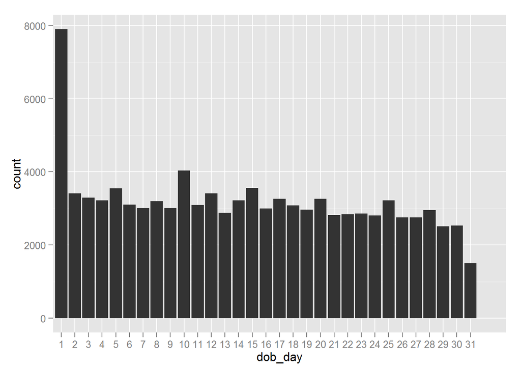

```r
# install.packages('ggplot2')
library(ggplot2)
qplot(data = pf, x = dob_day) +
  scale_x_discrete(breaks=1:31)
```

#### What are some things that you notice about this histogram?

Response: - We find that the graph is roughly uniform distributed for data. - The bar for 31 is smaller but expected since only 7 months in a year have 31 days. - The one bar that stands out is for 1st of the month. But this probably indicates we don’t have data for all subjects and the model defaulted to 1 in case of N/A.

### Moira’s Investigation

Notes: http://hci.stanford.edu/publications/2013/invisibleaudience/invisibleaudience.pdf ***

### Estimating Your Audience Size

Notes:

#### Think about a time when you posted a specific message or shared a photo on Facebook. What was it?

Response: Ski trip to Tahoe with selfies on Squaw and Kirkwood.

#### How many of your friends do you think saw that post?

Response: 30 friends or about 10%

#### Think about what percent of your friends on Facebook see any posts or comments that you make in a month. What percent do you think that is?

Response:

### Perceived Audience Size

Notes:

### Faceting

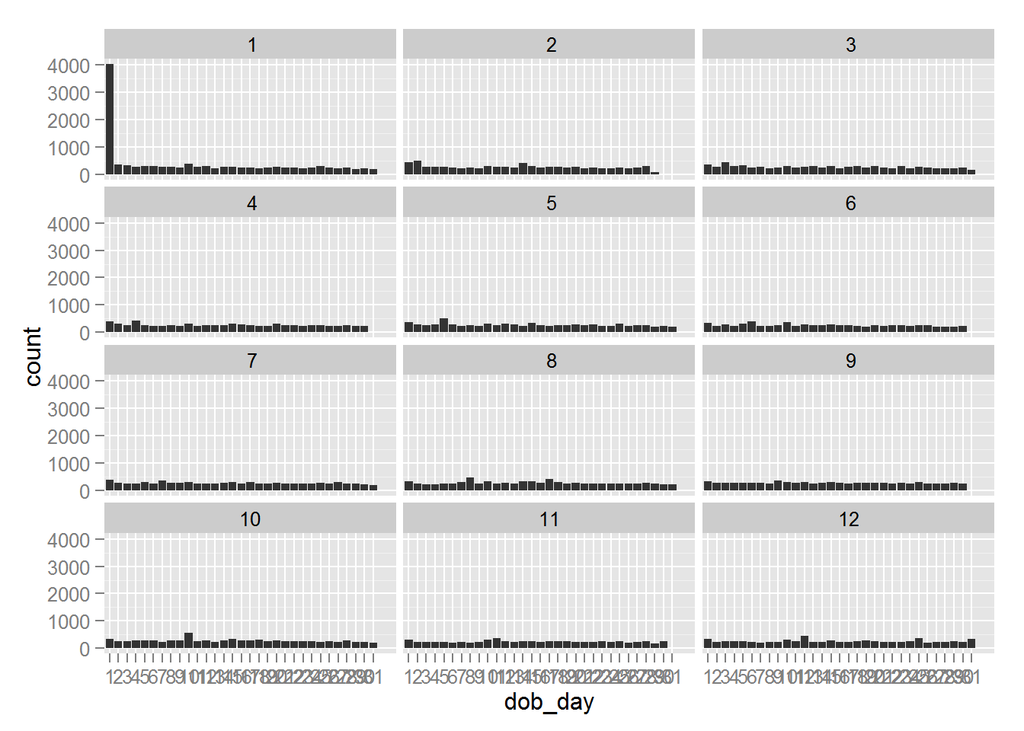

```r
qplot(data = pf, x = dob_day) +
  scale_x_discrete(breaks=1:31) +
  facet_wrap(~dob_month, ncol = 3)
```

#### Letâs take another look at our plot. What stands out to you here?

Response: - All the monthly histograms also look uniform as expected - Here, we see the spike for Jan 1st which must be the DOB default for FB

### Be Skeptical - Outliers and Anomalies

Notes: - Important thing to note is which anamolies are actually real and which ones are due to some issue with data - Top coded data - Sometimes, data points whose values are above an upper bound are censored - In general, it is important to think about which category an anamoly falls into, so that it can be adjusted or discarded before analysis

### Moira’s Outlier

Notes: #### Which case do you think applies to Moiraâs outlier? Response: Bad data about an extreme case

### Friend Count

Notes:

#### What code would you enter to create a histogram of friend counts?

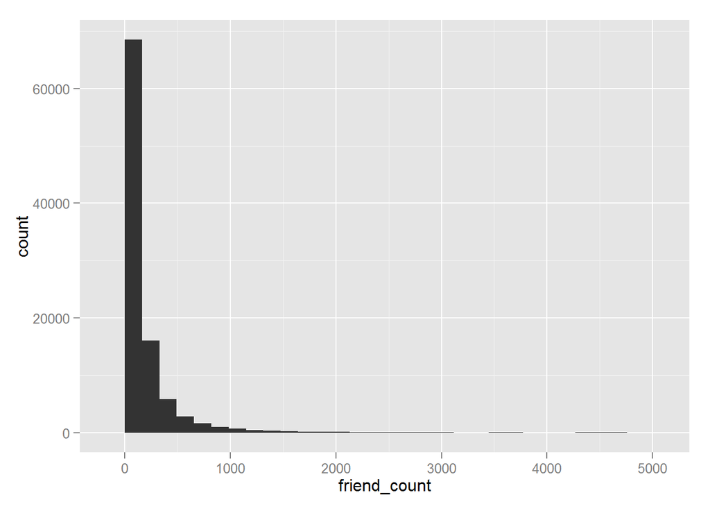

```r
qplot(data = pf, x = friend_count)
```

#### How is this plot similar to Moira’s first plot?

Response: - Data skewed to right meaning most people have 0-100 friends which falls into one bucket and a long tail

### Limiting the Axes

Notes: http://docs.ggplot2.org/current/scale_continuous.html - Since bulk of our data is for friend_count < 1000, we limit our histogram using xlim

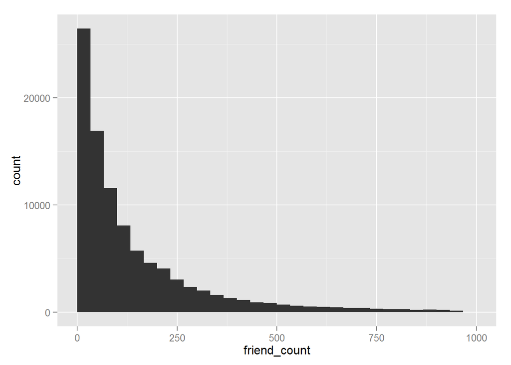

```r
qplot(data = pf, x = friend_count, xlim = c(0, 1000))
```

```r
# equivalent syntax
# qplot(data = pf, x = friend_count) +
#   scale_x_continuous(limits = c(0, 1000))
```

### Exploring with Bin Width

Notes:

### Adjusting the Bin Width

Notes:

### Faceting Friend Count

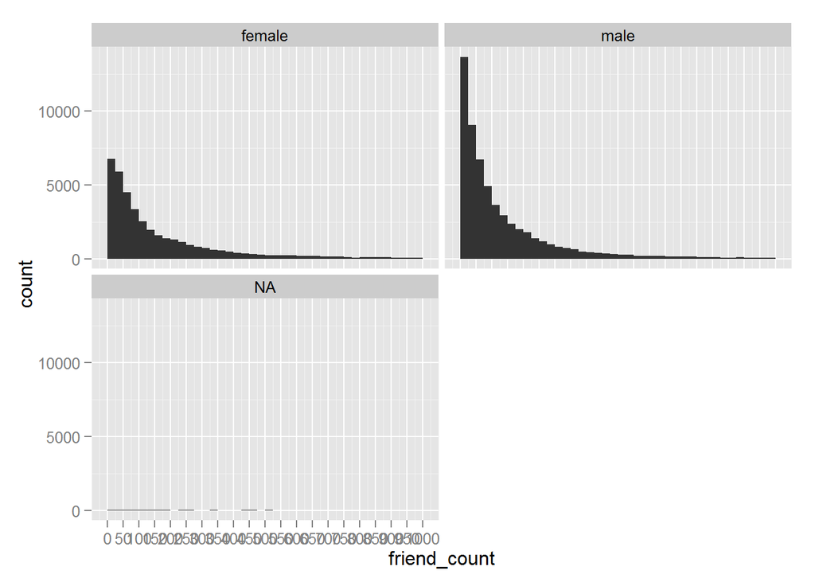

```r
# What code would you add to create a facet the histogram by gender?
# Add it to the code below.
qplot(x = friend_count, data = pf, binwidth = 25) +
  scale_x_continuous(limits = c(0, 1000), breaks = seq(0, 1000, 50)) +
  facet_wrap(~gender, ncol = 2)
```

### Omitting NA Values

Notes: - using na.omit(pf) instead will get rid of all observations that have NA in at least one variable - For this particular situation, might not be the best option - limits gives range of x axis - breaks states how often the ticks appear on the axis

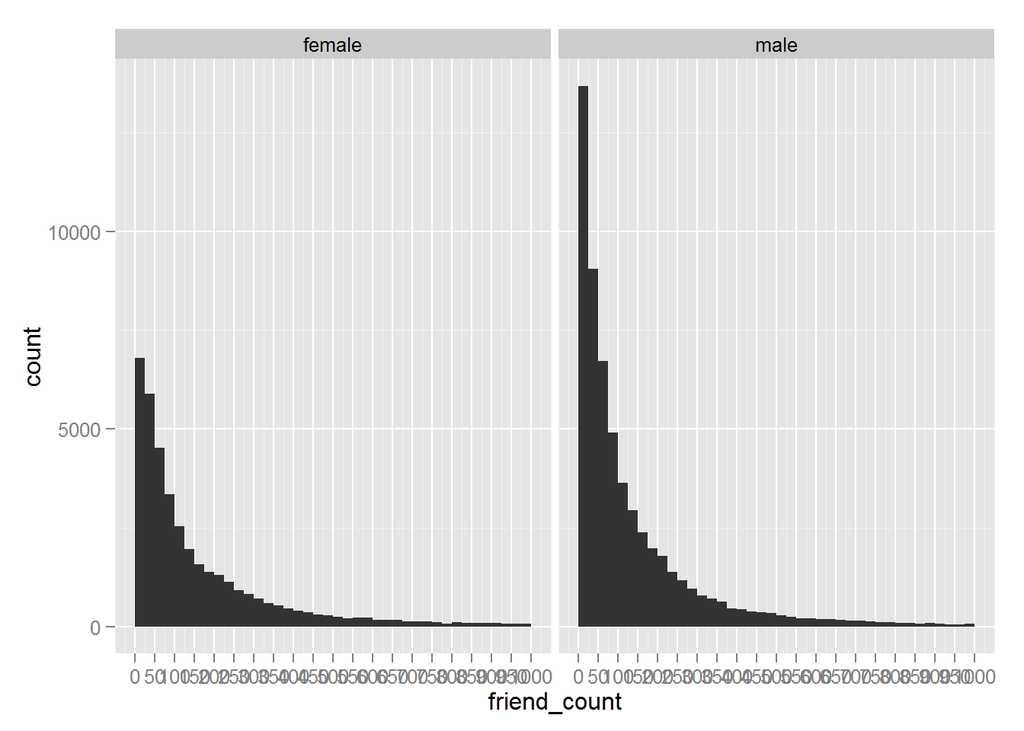

```r
qplot(x = friend_count, data = subset(pf, !is.na(gender)), binwidth = 25) +
  scale_x_continuous(limits = c(0, 1000), breaks = seq(0, 1000, 50)) +
  facet_wrap(~gender, ncol = 2)
```

```r
# qplot(x = friend_count, data = na.omit(pf), binwidth = 25) +
#   scale_x_continuous(limits = c(0, 1000), breaks = seq(0, 1000, 50)) +
#   facet_wrap(~gender, ncol = 2)
```